# Week 1 Assignment

## Loading and preprocessing the data

```r
library(ggplot2)
library(dplyr)
activity <- read.csv("activity.csv", colClasses = c("integer", "Date", "factor"))
activity$month <- as.numeric(format(activity$date, "%m"))
noNA <- na.omit(activity)
rownames(noNA) <- 1:nrow(noNA)
```

## What is the mean total number of steps taken per day?

Calculate the total number of steps taken per day:

```r
total.step <- aggregate(noNA$steps, list(Date = noNA$date), FUN = "sum")$x
```

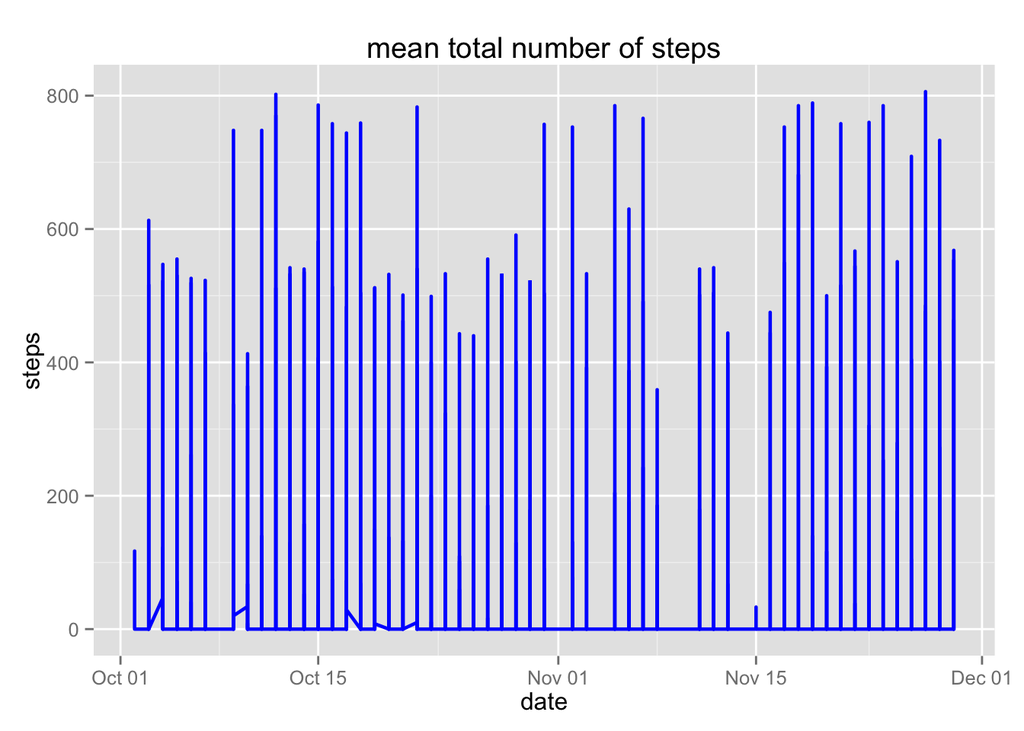

```r
ggplot(noNA, aes(date, steps)) + geom_line(color = "blue", size = 0.8) + labs(title = "mean total number of steps")
```

The mean and median of the total number of steps taken per day are:

```r
mean(total.step)
```

```
## [1] 10766.19
```

```r
median(total.step)
```

```
## [1] 10765
```

## What is the average daily activity pattern?

Make a time series plot:

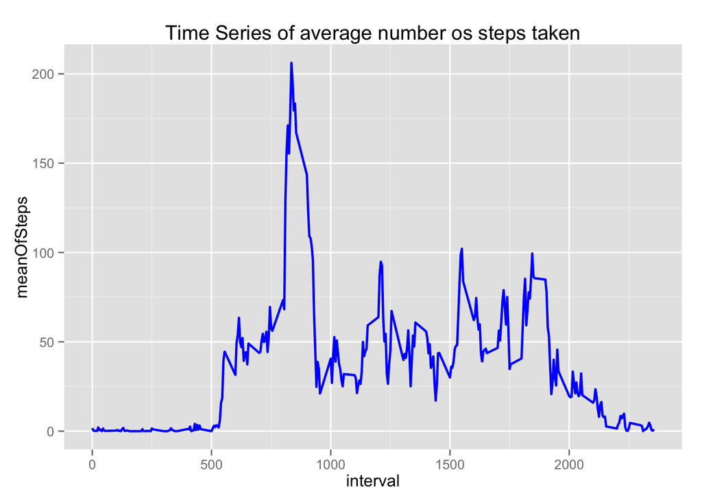

```r
avgSteps <- aggregate(noNA$steps, list(interval = as.numeric(as.character(noNA$interval))), FUN = "mean")
names(avgSteps)[2] <- "meanOfSteps"

ggplot(avgSteps, aes(interval, meanOfSteps)) + geom_line(color = "blue", size = 0.8) + labs(title = "Time Series of average number os steps taken")
```

Which 5-munite interval, on average across all the days in the dataset, contains the maximum number of steps:

```r
avgSteps[avgSteps$meanOfSteps == max(avgSteps$meanOfSteps), ]
```

```
##     interval meanOfSteps
## 104      835    206.1698
```

## Imputing missing values

Calculate the total number of missing values in the dataset:

```r
sum(is.na(activity))
```

```
## [1] 2304
```

Create a new dataset with missing value filled with average of that interval:

```r
newData <- activity
for (i in 1:nrow(newData)) {
    if (is.na(newData$steps[i])) {
        newData$steps[i] <- avgSteps[which(newData$interval[i] == avgSteps$interval), ]$meanOfSteps
    }
}
head(newData)
```

```
##       steps       date interval month
## 1 1.7169811 2012-10-01        0    10
## 2 0.3396226 2012-10-01        5    10
## 3 0.1320755 2012-10-01       10    10
## 4 0.1509434 2012-10-01       15    10
## 5 0.0754717 2012-10-01       20    10
## 6 2.0943396 2012-10-01       25    10
```

Make a histogram and report the mean and median total number of steps taken per day:

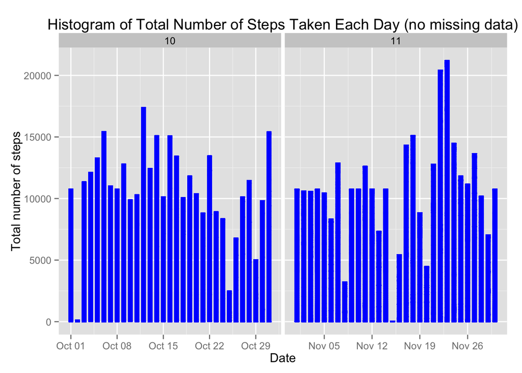

```r
ggplot(newData, aes(date, steps)) + geom_bar(stat = "identity",
                                             colour = "blue",
                                             fill = "blue",
                                             width = 0.6) + facet_grid(. ~ month, scales = "free") + labs(title = "Histogram of Total Number of Steps Taken Each Day (no missing data)", x = "Date", y = "Total number of steps")
```

```r
newTotalSteps <- aggregate(newData$steps, list(Date = newData$date), FUN = "sum")$x
newMean <- mean(newTotalSteps)
newMean
```

```
## [1] 10766.19
```

```r
newMedian <- median(newTotalSteps)
newMedian
```

```
## [1] 10766.19
```

Compare the newMean and newMedian with the two before:

```r
oldMean <- mean(total.step)
oldMedian <- median(total.step)

newMean - oldMean
```

```
## [1] 0
```

```r
newMedian - oldMedian
```

```
## [1] 1.188679
```

The new mean is the same as the old mean, while the new median is larger than the old median.

## Are there differences in activity patterns between weekdays and weekends?

Create a new factor indicating if a given day is a weekday or weekend:

```r
newData$weekdays <- factor(format(newData$date, "%A"))
levels(newData$weekdays)
```

```
## [1] "Friday"    "Monday"    "Saturday"  "Sunday"    "Thursday"  "Tuesday"
## [7] "Wednesday"
```

```r
levels(newData$weekdays) <- list(weekday = c("Monday", "Tuesday", "Wednesday", "Thursday", "Friday"), weekend = c("Saturday", "Sunday"))
levels(newData$weekdays)
```

```
## [1] "weekday" "weekend"
```

```r
table(newData$weekdays)
```

```
##
## weekday weekend
##   12960    4608
```

Make a panel plot containing a time series plot (i.e. type = “l”) of the 5-minute interval (x-axis) and the average number of steps taken, averaged across all weekday days or weekend days (y-axis).

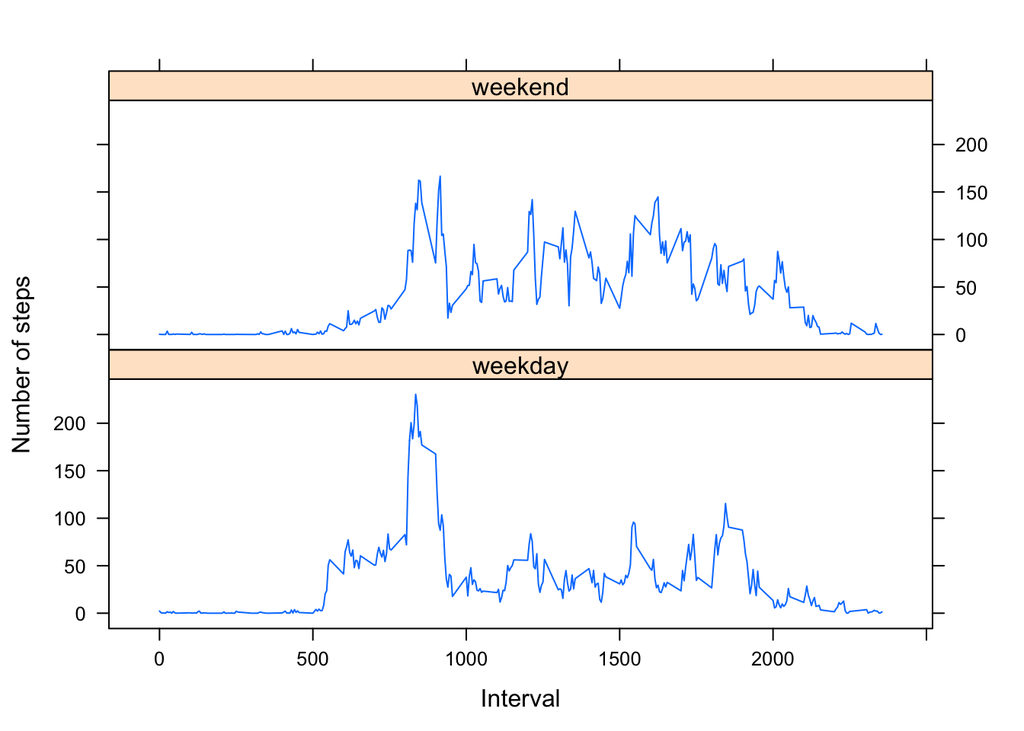

```r
avgSteps <- aggregate(newData$steps,
                      list(interval = as.numeric(as.character(newData$interval)),
                           weekdays = newData$weekdays),
                      FUN = "mean")
names(avgSteps)[3] <- "meanOfSteps"
library(lattice)
xyplot(avgSteps$meanOfSteps ~ avgSteps$interval | avgSteps$weekdays,
       layout = c(1, 2), type = "l",
       xlab = "Interval", ylab = "Number of steps")
```